# Sets

A set is a collection of elements where each elements without duplicates. This means that a set cannot contain the same element twice. For example, $\{1,2,3,a,b\}$ denotes a set but $\{1,1,2\}$ does not as the element $1$ is duplicated.

Sets can be either finite or infinite. Infinite sets contain a infinite numbers of elements.

In this course we are mainly interested in sets of numbers. The most useful examples are:

### The set of natural numbers

This is the set of numbers you learned to use in primary school. In this course we will consider $0$ to be a natural number.

$$ \mathbb{N} := \{0, 1, 2, 3, 4, ...\} $$

### The set of integers

Integers are natural numbers with a sign. Each natural number except for $0$ has its negative version:

$$ \mathbb{Z} := \{..., -2, -1, 0, 1, 2, ...\} $$

We will denote the positive integers as:

$$ \mathbb{Z}^{+} := \{1, 2, 3, 4, ...\} $$

and the negative integers as:

$$ \mathbb{Z}^{-} := \{-1, -2, -3, ...\} $$

### The set of rational numbers

Rational numbers are defined as ratios of integers: $$ \mathbb{Q} := \Big\{\frac{a}{b}\enspace|\enspace a,b\in\mathbb{Z}\wedge b\neq0\Big\} $$

We denote the set of rational numbers as $\mathbb{Q}$.

Note that two fractions can represent the same rational number. For example:

$$ \frac{1}{2} = \frac{2}{4} $$

### The set of real numbers

Not all numbers can be expressed as a ratio of integers. The simplest example is the square root of two: $\sqrt{2}$.

Numbers that are not rational are said to be irrational. The set of real numbers $\mathbb{R}$ contains both rational and irrational numbers. A real number is defined by a (usually infinite) sequence of digits. For example, the square root of two in base $10$ is:

$$ \sqrt{2} = 1.41421356237309504880168... $$

Note that two sequences of digits can represent the same number, for example:

$$ 1.00000000000... = 0.999999999... $$

real numbers can be decomposed into a fractional part and a integral part, for example:

$$ \sqrt{2} = 1 + 0.41421356237309504880168... $$

The true definition of $\mathbb{R}$ is not given since it's too complex for this course.

#### Bonus: Extraordinary proof

More formally, the fractional part of a real number can be defined as the limit of a infinite sum. Consider a infinite sequence of digits: $$ A = A_1, A_2, A_3, ... $$ from these digits, we can construct a real number $a$ as the following infinite sum of rational numbers $$ x = \displaystyle\sum_{n=1}^\infty \frac{A_n}{10^n} $$ Note that the division by a power of ten places the digits in the right position in the decimal expansion: $$ \begin{aligned} &0.\color{blue}{4}\color{red}{1}\color{green}{4}\color{purple}{2}... = \\ &0.\color{blue}{4}000... + \\ &0.0\color{red}{1}00... + \\ &0.00\color{green}{4}0... + \\ &0.000\color{purple}{2}... + \\ \end{aligned} $$

using this definition, it is easy to see that $1.0000000000...$ = $0.9999999999$:

$$ 1.00000... = 1 + \sum_{n=1}^\infty \frac{0}{10^n} = 1 $$$$ 0.99999... = 0 + \sum_{n=1}^\infty \frac{9}{10^n} = 9 \sum_{n=1}^\infty (0.1)^n = 9 \left(\sum_{n=0}^\infty (0.1)^n - 1 \right) = 9 \left(\frac{1}{1 - 0.1} - 1 \right) = 1 $$

where I used the formula for summing the infinite geometric series (see lecture 1).

```python
import matplotlib.pyplot as plt
import numpy as np
```

# Functions

In this lecture we are going to discuss functions. A function between the set $A$ and a set $B$ is defined as a "rule" that assigns one and only one element of $B$ for each element of $A$.

We denote a function from $A$ to $B$ as follows:

$$ f:A \rightarrow B $$

For each element $a$ of $A$, we denote the corresponding element of $B$ as $f(a)$. The (input) set $A$ is called domain while the (output) set $B$ is called codomain.

The following figure visualize a function from the set (of characters) $A = \{a, b, c\}$ to the set (of numbers) $B = \{1, 2\}$.

[figure not shown]

A function can be seen as a (potentially infinite) table of pairs. For example, the function in the image is defined by the following table: $$ \begin{aligned} &(a, f(a)) = (a, 1) \\ &(b, f(b)) = (b, 2) \\ &(c, f(c)) = (c, 2) \end{aligned} $$

## Interlude: functions in Python

there are two ways for defining a function in Python. The first is using a def statment:

```python
def square(n):
    return n**2
```

Alternatively, we can define the same function using a lambda expression:

```python
square = lambda n: n**2
```

### Bonus excercises

Write the following functions in Python using lambda expressions:

- $f_1: \mathbb{R} \rightarrow \mathbb{R}, \quad f_1(x) = x$
- $f_2: \mathbb{N} \rightarrow \mathbb{R}, \quad f_2(n) = n^2$
- $f_3: \mathbb{R} \rightarrow \mathbb{R}, \quad f_3(x) = x^2$

## Injective functions

A function $f:A \rightarrow B$ is said to be injective if, for all different $a_1$ and $a_2$ in $A$, $f(a_1)$ is always different from $f(a_2)$. In other words, a injective function never maps to elements of $A$ on the same element of $B$.

The function in the previous figure is not injective as $f(b) = f(c) = 2$.

### Exercises

#### 2.1

Are the following functions injective?

**a)** $f_1: \mathbb{R} \rightarrow \mathbb{R}, \quad f_1(x) = x$

**b)** $f_2: \mathbb{N} \rightarrow \mathbb{R}, \quad f_2(n) = n^2$

**c)** $f_3: \mathbb{R} \rightarrow \mathbb{R}, \quad f_3(x) = x^2$

## Surjective functions

The range (or image) of a function is the set of its values. We will denote the range of $f$ as $f(A)$:

$$ f(A) = \{f(a) \enspace | \enspace \forall a\in A\} $$

Clearly, the range of a function $f: A \rightarrow B$ is a subset of $B$. The function $f$ is said to be surjective when its range is identical to B. This means that all elements of $B$ can be written as $f(a)$ for some $a$ in $A$.

The function in the figure is surjective as $f(A) = \{f(a), f(b)\} = \{1, 2\} = B$.

### Exercises

#### 2.2

Are the following functions surjective?

**a)** $f_1: \mathbb{R} \rightarrow \mathbb{R}, \quad f_1(x) = x$

**b)** $f_2: \mathbb{N} \rightarrow \mathbb{R}, \quad f_2(n) = n$

**c)** $f_3: \mathbb{R} \rightarrow \mathbb{R}, \quad f_3(x) = x^2$

## Bijective functions and their inverse function

A function is said to be bijective (one-to-one correspondence) when it is both injective and surjective. This means that each element $b$ of $B$ can be written as $f(a)$ in a unique way. When a function $f:A \rightarrow B$ is bijective, it is possible to obtain a inverse function $f^{-1}: B \rightarrow A$ such that:

$$ f^{-1}(f(a)) = a $$

and

$$ f(f^{-1}(b)) = b $$

The inverse function is obtained simply by reversing the order of the pairs. For example, the inverse of:

$$ \begin{aligned} &(1, f(1)) = (1, 1) \\ &(2, f(2)) = (2, 3) \\ &(3, f(3)) = (3, 2) \end{aligned} $$

is

$$ \begin{aligned} &(1, f^{-1}(1)) = (1, 1) \\ &(3, f^{-1}(3)) = (3, 2) \\ &(2, f^{-1}(2)) = (2, 3) \end{aligned} $$

Note that this is possible only if the function is bijective since:

1) $f^{-1}(b)$ needs to be defined $\forall b\in B$, this is possible only if $f$ is surjective.

2) $f^{-1}(b)$ has to be uniquely defined. This is only true when $f$ is injective.

### Examples

- The function $f_1(x) = x$ is equal to its own inverse.
- The inverse of $f_2(x) = x + 1$ is $f_2^{-1}(x) = x - 1$.
- The inverse of $f_3(x) = 3 x$ is $f_3^{-1}(x) = \frac{x}{3}$

### Exercises

#### 2.4

Find the inverse of the following functions:

**a)** $f_1(x) = 6x$

**b)** $f_2(x) = 3+4x^3$

**c)** $f_3(x) = 3\cdot(10)^{x+1}$

**d)** $f_4(x) = \mathrm{e}^{4x+1}$

# A library of functions

We are now going to discuss some simple example of functions from $\mathbb{R}$ to $\mathbb{R}$.

## Constant functions

Constant functions are the simplest possible functions. They map all the input to a single value:

$$ f(x) = c $$

Clearly, constant functions are not injective as all $x$ in $R$ are mapped to a single value.

here is the graph of $f(x) = 2 \ldots $ not very exciting!

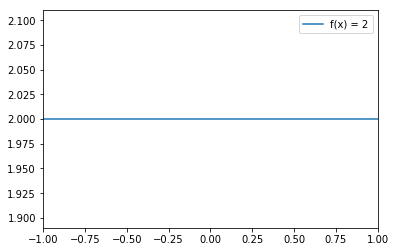

```python
f = lambda x: 2

x_range = np.linspace(-1,1,100)
p = 3

plt.plot(x_range, [f(x) for x in x_range], label="f(x) = 2")
plt.xlim(min(x_range), max(x_range))
plt.legend(loc="best")
```

## Linear functions

linear functions are obtained by multiplying the input by a factor:

$$ f(x) = a x $$

If the factor $a$ is equal to zero, the function is the $f(x) = 0$ constant function. Otherwise, the linear function is one-to-one and its inverse is given by:

$$ f^{-1}(x) = \dfrac{x}{a} $$

note that the inverse of a linear function is itself a linear function. Here is the plot of the function $f(x) = 2 x$ and its inverse:

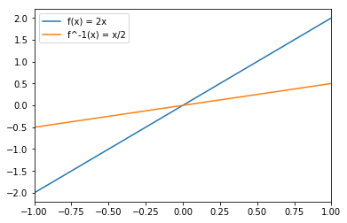

```python
f = lambda x: 2*x
f_inv =  lambda x: x/2

x_range = np.linspace(-1,1,100)
p = 3

plt.plot(x_range, [f(x) for x in x_range], label="f(x) = 2x")
plt.plot(x_range, [f_inv(x) for x in x_range], label="f^-1(x) = x/2")
plt.xlim(min(x_range), max(x_range))
plt.legend(loc="best")
```

## Powers and roots

Powers functions are obtained by taking a integer power of the input:

[figure not shown]

When the power $p$ is odd, the function is one-to-one and it can be inverted. Conversely, when $p$ is even, the function is one-to-one only if we restrict the domain to non-negative real numbers. The inverse is given by the $p$-th root function:

$$ f_p^{-1}(x) = \sqrt[p]{x} $$

Note that, when $p$ is even, $\sqrt[p]{x}$ is defined only when $p$ is non-negative.

We can now plot the graph of some power functions:

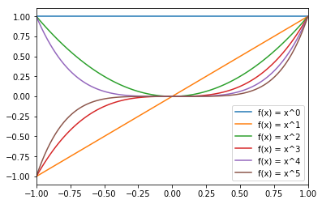

```python
f = lambda x,p: x**p

for p in range(6):
    plt.plot(x_range, f(x_range, p), label="f(x) = x^{}".format(p))
plt.xlim(min(x_range), max(x_range))
plt.legend(loc="best")
```

and of the corresponding root functions:

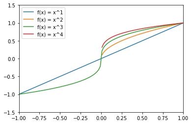

```python
def f_inv(x, p):
    if x>= 0:
        return x**(1/p)
    else:
        if p%2 == 0:
            return np.nan
        else:
            return -(abs(x))**(1/p)

for p in range(1,5):
    plt.plot(x_range, [f_inv(x, p) for x in x_range], label="f(x) = x^{}".format(p))
plt.xlim(min(x_range), max(x_range))
plt.ylim(-1.5, 1.5)
plt.legend(loc="best")
```

Root functions can also be written as fractional roots:

$$ \sqrt[p]{x} = x^{\frac{1}{p}} $$

In fact, since roots are the inverse functions of powers, we have that:

$$ (x^p)^{\frac{1}{p}} = x^{\frac{p}{p}} = x^1 = x $$

## Polynomials

Polynomials are one of the most important class of functions. A polynomial is a scaled sums of powers:

$$ f(x) = \displaystyle\sum_{p=0}^P \beta_p x^p $$

where the coefficients $\beta_p$ are all real numbers. Constant functions, linear functions and powers are all special cases of polynomials. The highest power $P$ in a polynomial is called its degree. Second degree polynomials are called quadratic while third degree polynomials are called cubic.

```
(-3.0, 3.0)
```

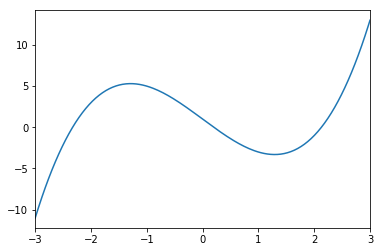

```python
x_range = np.linspace(-3,3,200)

f = lambda x: 1 - 5*x + x**3

plt.plot(x_range, [f(x) for x in x_range], label="f(x) = x^{}".format(p))
plt.xlim(min(x_range), max(x_range))
#plt.ylim(-1.5, 1.5)
```

As you can see from the graph, polynomials are not always injective as they can assume the same values at multiple points.

## Rational functions

Rational functions are defined as ratios of polynomials:

$$ f(x) = \dfrac{\displaystyle\sum_{p=0}^P \beta_p x^p}{\displaystyle\sum_{k=0}^K \alpha_k x^k} $$

The domain of a rational function is the set of real number minus a finite number of points corresponding to the roots of the polynomial in the denominator (a root of a function is a point where the value of the function is zero). The domain of a rational function cannot clearly include these points as it would imply a division by zero.

Consider the following rational function:

$$ f_1(x) = \dfrac{1 + x^2 - 10 x^3}{x} $$

The polynomial in the denominator is zero only at zero, therefore the domain of this rational function is the set of all non-zero real numbers:

$$ \mathbb{R}\backslash \{0\} $$

here is the graph:

```
(-50, 50)
```

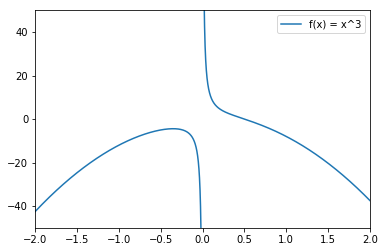

```python
f = lambda x: (1+x**2 - 10*x**3)/x if np.abs(x)>10**-3 else np.nan

x_range = np.linspace(-2,2,10000)
p = 3

plt.plot(x_range, [f(x) for x in x_range], label="f(x) = x^{}".format(p))
plt.xlim(min(x_range), max(x_range))
plt.legend(loc="best")
plt.ylim(-50,50)
```

Note that the function tend to +- infinity near zero.

### Excercises

#### 2.5

Find the domain of the following rational functions:

**a)** $f_1(x) = \dfrac{1}{1 + x^2}$

**b)** $f_2(x) = \dfrac{1 + x^2}{1 - x^2}$

**c)** $f_3(x) = \dfrac{x^{42}}{1 + x - x^2}$

**d)** $f_4(x) = \dfrac{1 + x}{x^2}$

Hint: you need to solve the algebraic equation denominator(x) = 0. For example, in the case of $f_1$ you need to solve the following equation: $$ 1 + x^2 = 0 $$

## The exponential function

The esponential function is positive-valued and its domain is the whole set of real numbers. The most important property of the exponential is that it converts sums into products:

$$ \exp(a+b) = \exp(a)\cdot\exp(b) $$

From this property, we can see that:

$$ \exp(x) = \exp(0 + x) = \exp(0)\cdot\exp(x) $$

Hence:

$$ \exp(0) = 1 $$

Furthermore:

$$ 1 = \exp(0) = \exp(x + (- x)) = \exp(x)\cdot\exp(-x) $$

Hence:

$$ \exp(-x) = \dfrac{1}{\exp(x)} $$

### Exponential function with integer inputs

Let's consider the case where the input of the exponential function is a natural number:

$$ \exp(n) $$

Using the property of the exponential, we can derive a simple recursive relation:

[figure not shown]

Thereforem when $n$ is a integer the exponential can be written as the number $\exp(1)$ to the $n$-th power. This number is called the Euler constant (denoted as $e$) and it is defined by the following infinite sum:

$$ \mathrm{e} = \exp(1) = \displaystyle\sum_{n=1}^\infty \dfrac{1}{n!} $$

Therefore, we can write $\exp(n)$ as

$$ \mathrm{e}^n $$

Similarly, we will sometime write

$$ \exp(x) = \mathrm{e}^x $$

note that this is just a convenient notation as it does not make sense to say that the number $\mathrm{e}$ should be multiplied by itself $x$ times when $x$ is not a integer.

### The natural logarithm

The natural logarithm is the inverse function of the exponential:

$$ \log(\exp(x)) = \exp(\log(x)) = x $$

Since the exponential is positive-valued, the domain of the logarithm is the set of positive real numbers. In other words, we cannot define the logarithm of a negative number (or of zero) as the value of the exponential is always positive.

Being the inverse of the exponential, the logarithm converts products into sums:

$$ \log(a \cdot b) = \log(a) + \log(b) $$

The logarithm also converts ratios into differences:

$$ \log\Big(\dfrac{a}{b}\Big) = \log(a) - \log(b) $$

### Exponential functions with different bases

There are infinitely many other version of the exponential function all respecting the property:

$$ y^a y^b = y^{a+b} $$

when $a$ and $b$ are integers these functions are easy to define:

[figure not shown]

we now need to define $y^x$ when $x$ is a arbitrary real number. We can define this using the exponential function and the logarithm. In fact, the number $y$ can be written as follows:

$$ y = \exp(\log(y)) $$

Hence:

$$ y^x = \exp(\log(y))^x = (\mathrm{e}^{\log(y)})^x = \mathrm{e}^{x \log(y)} $$

```
Text(0.5,1,'Exponential function and truncation of its power series')
```

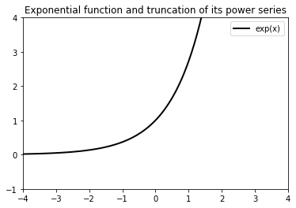

```python
from scipy.special import factorial
x_range = np.linspace(-4,4,100)

plt.plot(x_range, np.exp(x_range), c="k", lw=2, label="exp(x)")
plt.xlim(-4,4)
plt.ylim(-1,4)
plt.legend(loc="best")
plt.title("Exponential function and truncation of its power series")
```

```
Text(0.5,1,'Logarithm')
```

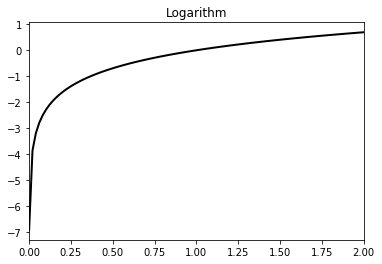

```python
x_range = np.linspace(0.001,2,100)
plt.plot(x_range, np.log(x_range), c="k", lw=2)
plt.xlim(0,2)
plt.title("Logarithm")
```

## Trigonometric functions

The trigonometric functions are strictly connected with circles. The equation for a circle centered at the origin with radius one is:

$$ \color{blue}{x^2} + \color{green}{y^2} = 1 $$

Each point in the circle is uniquely defined by a angle $\color{purple}{\theta}$ ranging from $0$ to $2 \pi$ radians. Points in the circle can then be expressed as function of the angle using the cosine and the sine function:

$$ \color{blue}{\cos(\color{purple}{\theta})^2} + \color{green}{\sin(\color{purple}{\theta})^2} = 1~. $$

[figure not shown]

Therefore, the cosine gives the $x$ coordinate of a point in a circle of radius one while the sine gives the $y$ coordinate.

From the diagram is clear that, when $\color{purple}{\theta}$ is equal to zero, the sine is equal to zero while the cosine is equal to one. Conversely, the cosine is zero and the sine is one when $\color{purple}{\theta}$ is equal to $\pi/2$.

The result are functions that oscillate up and down:

```
Text(0.5,1,'Trigonometric functions')
```

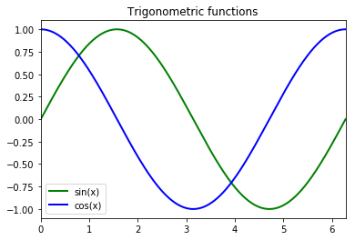

```python
x_range = np.linspace(0,2*np.pi,300)

plt.plot(x_range, np.sin(x_range), lw=2, label="sin(x)", c="g")
plt.plot(x_range, np.cos(x_range), lw=2, label="cos(x)", c="b")
plt.xlim(0,2*np.pi)
plt.legend(loc="best")
plt.title("Trigonometric functions")
```

We can also extend these functions to the whole real axis by assuming that they are periodic with period $2 \pi$.

```
Text(0.5,1,'Trigonometric functions')
```

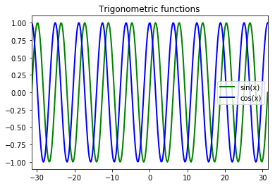

```python
x_range = np.linspace(-10*np.pi,10*np.pi,300)

plt.plot(x_range, np.sin(x_range), lw=2, label="sin(x)", c="g")
plt.plot(x_range, np.cos(x_range), lw=2, label="cos(x)", c="b")
plt.xlim(-10*np.pi,10*np.pi)
plt.legend(loc="best")
plt.title("Trigonometric functions")
```

### Important trigonometric identities

There are many important identities relating the values of the trigonometric functions. You can find a comprehensive list [here](https://en.wikipedia.org/wiki/List_of_trigonometric_identities).

We already introduced the most important identity:

$$ \cos(x)^2 + \sin(x)^2 = 1 ~. $$

Other two very important identities can be used for doubling the angle:

$$ \sin(2x) = 2\cos(x)\sin(x) $$$$ \cos(2x) = \cos(x)^2 - \sin(x)^2 $$

These are special cases of formulas for summing angles:

$$ \sin(x + y) = \cos(x)\sin(y) + \cos(y)\sin(x) $$$$ \cos(x + y) = \cos(x)\cos(y) - \sin(y)\sin(x) $$

We can also invert the angle doubling formula to get angle halfing formulas:

$$ \sin\Big(\frac{x}{2}\Big)^2 = \frac{1 - \cos(x)}{2} $$$$ \cos\Big(\frac{x}{2}\Big)^2 = \frac{1 + \cos(x)}{2} $$

### Exercises

#### 2.6

Compute the following values using trigonometric identities:

**a)** $\cos(\pi/2) = ?$

**b)** $ \cos(\pi/4) = ? $

**c)** $ \cos(\pi/8) = ? $

**d)** $ \sin(\pi/2) = ? $

**e)** $ \sin(\pi/4) = ? $

**f)** $ \sin(\pi/8) = ? $

## The tangent and the inverse trigonometric functions

The tangent is defined as the ration between sine and cosine:

$$ \tan{(x)} = \dfrac{\sin(x)}{\cos(x)} $$

Clearly, this expression makes sense only when the denominator is different from zero (you can't divide by zero!). Therefore, the domain of the tangent is the set of real numbers $z$ such that $\cos(z) \neq 0$.

```
Text(0.5,1,'Tangent')
```

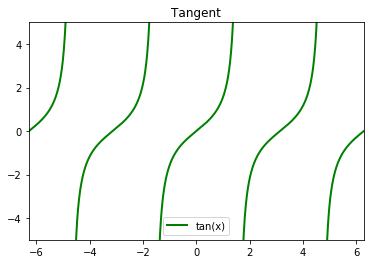

```python
x_range = np.linspace(-2*np.pi,2*np.pi,1000)

f = lambda x: np.tan(x) if np.abs(np.cos(x))>0.01 else np.nan

plt.plot(x_range, [f(x) for x in x_range], lw=2, label="tan(x)", c="g")
plt.xlim(-2*np.pi,2*np.pi)
plt.ylim(-5,5)
plt.legend(loc="best")
plt.title("Tangent")
```

As you can see from the graph, the tangent is periodic with period $\pi$.

### Inverse functions

Sine, cosinge and tangents are periodic and therefore they are clearly not one-to-one. This means that we cannot define their inverses.

For example, there are infinitly many values of $x$ such that:

$$ \cos(x) = 1 $$

In particular, we have that:

$$ \cos(n 2 \pi) = 1 $$

for all possible integers $n$.

#### The arcosine function

However, can can define the inverse functions of the restriction of the trigonometric functions to a smaller domain. For example, consider the sine function defined between $-\dfrac{\pi}{2}$ and $\dfrac{\pi}{2}$:

```
Text(0.5,1,'restriction of the sine function')
```

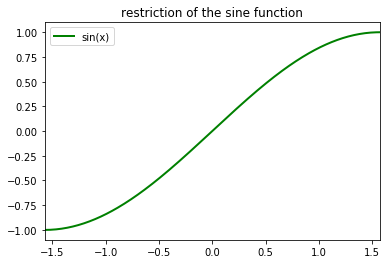

```python
x_range = np.linspace(-np.pi/2,np.pi/2,300)

plt.plot(x_range, np.sin(x_range), lw=2, label="sin(x)", c="g")
plt.xlim(-np.pi/2,np.pi/2)
plt.legend(loc="best")
plt.title("restriction of the sine function")
```

As you can see from the graph, the sine is one-to-one in this interval. This imply that we can define the inverse function of this restriction.

We denote the inverse of the sine between $-\dfrac{\pi}{2}$ and $\dfrac{\pi}{2}$ as:

$$ \arcsin(x) $$

Sine the values of the sine are between $-1$ and $1$, the dimain of the arcosine is the interval between $-1$ and $1$. Here is its graph

```
Text(0.5,1,'Arcosine function')
```

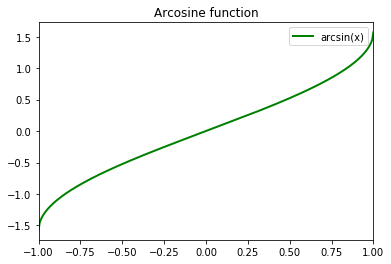

```python
x_range = np.linspace(-1,1,300)

plt.plot(x_range, np.arcsin(x_range), lw=2, label="arcsin(x)", c="g")
plt.xlim(-1,1)
plt.legend(loc="best")
plt.title("Arcosine function")
```

#### The arccosine function

Similarly, we can define the arccosine function by restrincting the cosine in the interval between $0$ and $\pi$:

```
Text(0.5,1,'Restriction of the cosine function')
```

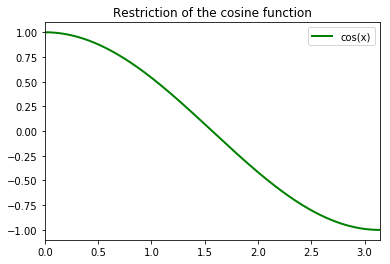

```python
x_range = np.linspace(0,np.pi,300)

plt.plot(x_range, np.cos(x_range), lw=2, label="cos(x)", c="g")
plt.xlim(0,np.pi)
plt.legend(loc="best")
plt.title("Restriction of the cosine function")
```

```
Text(0.5,1,'Arcocosine function')
```

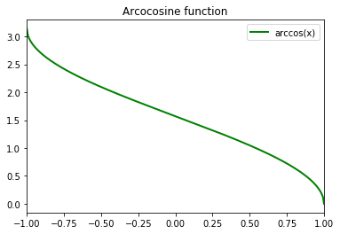

```python
x_range = np.linspace(-1,1,300)

plt.plot(x_range, np.arccos(x_range), lw=2, label="arccos(x)", c="g")
plt.xlim(-1,1)
plt.legend(loc="best")
plt.title("Arcocosine function")
```

#### The arctangent function

```
Text(0.5,1,'restriction of the tangent function')
```

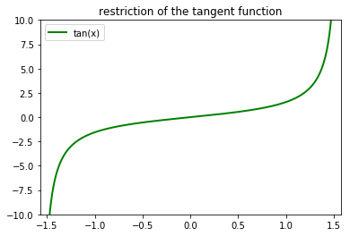

```python
x_range = np.linspace(-np.pi/2,np.pi/2,300)

plt.plot(x_range, np.tan(x_range), lw=2, label="tan(x)", c="g")
plt.xlim(-np.pi/2,np.pi/2)
plt.ylim(-10,10)
plt.legend(loc="best")
plt.title("restriction of the tangent function")
```

The arctangent function is the inverse of the tangent in this interval. Its domain is the whole set of real numbers since tangent assumes all possible values.

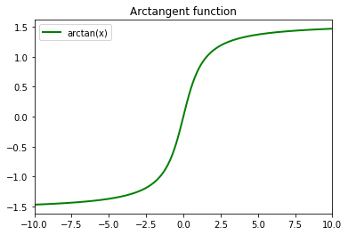

```python
x_range = np.linspace(-10,10,300)

plt.plot(x_range, np.arctan(x_range), lw=2, label="arctan(x)", c="g")
plt.xlim(-10,10)
plt.legend(loc="best")
plt.title("Arctangent function")
```

# Limits of a function

Limits of functions can be defined in a similar way than limits of sequences. Consider a function $f(x)$ and a point $x_0$. If $l$ is the limit of $f(x)$ at $x_0$, we write:

$$ \displaystyle\lim_{x\rightarrow x_0} f(x) = l $$

## Definition

The function $f(x)$ is said to have limit $l$ for $x$ tending to $x_0$ when:

For all $\epsilon > 0$, there is a $\delta_\epsilon > 0$ such that:

$$ |f(x) - l| \leq \epsilon $$

for all values of $x$ such that $|x - x_0| < \delta$.

In other words, for any possible small quantity $\epsilon$ there has to be another small quantity $\delta_\epsilon$ such that every time the input $x$ of the function is less than $\delta_\epsilon$ away from the limit point $x_0$, then the value of the function $f(x)$ is less than $\epsilon$ away from the limit $l$.

This can be visualized as follows:

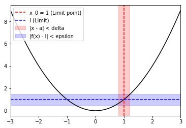

```python
f = lambda x: x**2

x_range = np.linspace(-3,3,100)
plt.plot(x_range, f(x_range), c="k")
a = 1
#plt.scatter(a, f(a), c="r")
epsilon = 0.5
plt.fill_between(x_range, f(a)-epsilon, f(a)+epsilon, alpha = 0.2, color = "b", label = "|f(x) - l| < epsilon")
delta = 0.2
plt.axvspan(a - delta, a + delta, alpha=0.2, color='red', label = "|x - a| < delta")
plt.axvline(x=1, c="r", ls="--", label="x_0 = 1 (Limit point)")
plt.axhline(y=f(1), c="b", ls="--", label="l (Limit)")
plt.xlim(min(x_range), max(x_range))
plt.legend(loc="upper left")
```

The black line is the graph of the function $f(x)$. The red dashed line denotes the location of the limit point $x_0$ while the blue dashed line denotes the value of the limit. The blue shaded area is the region that is not more than $\epsilon$ away from the limit $l$. The definition of the limit says that for any blue shaded areas around the limit there has to be a red shaded area around $x_0$ such that the graph of the function within this red shaded area is fully contained within the blue shaded area.

Let's consider a situation where the limit does not exist and it is not always possible to draw the red shaded area. Consider the following function:

$$ \begin{equation} f(x)=\begin{cases} x^2, & \text{if x < 1}.\\ x^2 + 1, & \text{otherwise}. \end{cases} \end{equation} $$

Let's try to see if this function has a limit for $x$ tending to $x_0 = 1$. We can start with the guess that the limit is equal to $1$ and see what happens. Let's consider $\epsilon = 2$. in this case, we can find a $\delta_\epsilon$ such that the graph is fully contaned in the blue shaded area as far as we are in the red shaded area.

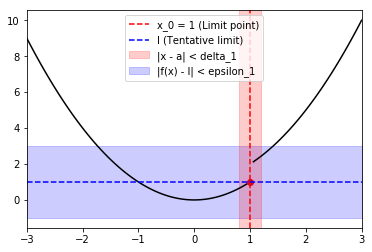

```python
def f(x):
    if x < 1:
        return x**2
    elif x == 1.:
        return np.nan
    else:
        return 1 + x**2

x_range = np.linspace(-3,3,100)
plt.plot(x_range, [f(x) for x in x_range], c="k")
a = 1
l = 1.
plt.scatter(a, l, c="r")
epsilon1 = 2
plt.fill_between(x_range, l-epsilon1, l+epsilon1, alpha = 0.2, color = "b", label = "|f(x) - l| < epsilon_1")
delta1 = 0.2
plt.axvspan(a - delta1, a + delta1, alpha=0.2, color='red', label = "|x - a| < delta_1")
plt.xlim(min(x_range), max(x_range))
plt.axvline(x=1, c="r", ls="--", label="x_0 = 1 (Limit point)")
plt.axhline(y=1, c="b", ls="--", label="l (Tentative limit)")
plt.legend(loc="best")
plt.show()
```

This is a good first step. However, in order to prove that $1$ is really the limit this property needs to hold for all possible values of $\epsilon$. Let's see what happens if $\epsilon$ is equal to $0.5$.

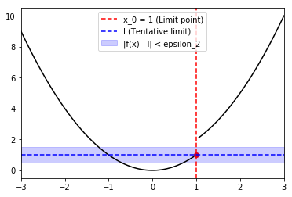

```python
plt.plot(x_range, [f(x) for x in x_range], c="k")
a = 1
l = 1.
plt.scatter(a, l, c="r")
epsilon1 = 1.2
delta1 = 0.2
epsilon2 = 0.5
plt.fill_between(x_range, l-epsilon2, l+epsilon2, alpha = 0.2, color = "b", label = "|f(x) - l| < epsilon_2")
plt.xlim(min(x_range), max(x_range))
plt.axvline(x=1, c="r", ls="--", label="x_0 = 1 (Limit point)")
plt.axhline(y=1, c="b", ls="--", label="l (Tentative limit)")
plt.legend(loc="best")
plt.show()
```

In this case you can see that is is impossible to find a $\delta_\epsilon$ that satsfies the property since every small interval around $x_0 = 1$ will always contains a small part on the right side of one that is always more than $1$ away from $l = 1$ since the function has a jump of size one at that point.

therefore, we can conclude that $1$ is not the limit of this function at $x_0 = 1$.

## Limits at infinity

The limit at infinity is defined in a similar way. A function $f(x)$ has limit $l$ for $x$ tending to $\infty$ when for all $L > 0$, there is a $x_L > 0$ such that:

$$ f(x) > L $$

for all $x$ bigger than $x_L$.

This definition can again be visualized using shaded areas:

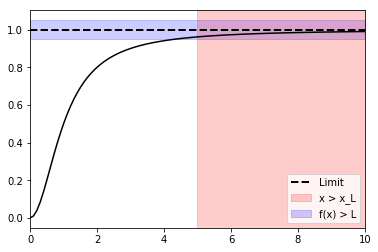

```python
f = lambda x: x**2/(1 + x**2)

x_range = np.linspace(0,10,100)
plt.plot(x_range, f(x_range), c="k")
l = 1
plt.axhline(l, c = "k", lw = 2, ls = "--", label="Limit")
epsilon = 0.05
plt.fill_between(x_range, l-epsilon, l+epsilon, alpha = 0.2, color = "b", label = "f(x) > L")
X = 5
plt.axvspan(X, max(x_range), alpha=0.2, color='red', label = "x > x_L")
plt.xlim(min(x_range), max(x_range))
plt.legend(loc="best")
```

# Continuous functions

The concept of continuity is very important in caclulus. A function $f(x)$ is sais to be continuous at a point $x_0$ if the function has a limit for $x$ tending to $x_0$ and the limit is equal to the value of the function.

In formulas, a function $f(x)$ is continuous at $x_0$ when it has a limit at $x_0$ and: $$ f(x) = \displaystyle\lim_{x \rightarrow x_0} f(x) $$

The function $f(x)$ is said to be continuous if it is continuous at all possible points. The intuition behind continuous functions is quite straightforward. Continuous are functions never jump!

# Asymptotic relations

We can define asymptotic relations between functions in a similar way we already did in the case of sequences. Let $x_0$ be a point in the domains of the functions $f(x)$ and $g(x)$. $f(x)$ is said to be asymptotic to $g(x)$ for $x$ tending to $x_0$ when:

$$ \displaystyle\lim_{x \rightarrow x_0} \dfrac{f(x)}{g(x)} = \displaystyle\lim_{x \rightarrow x_0} \dfrac{g(x)}{f(x)} = 1 $$

Note that this definition depends on the choice of the limit point $x_0$. For example, $x^2 + x$ is asymptotic to $x$ for $x$ tending to $0$ but it is instead asymptotic to $x^2$ for $x$ tending to infinity:

For $x$ tending to $0$:

$$ \displaystyle\lim_{x \rightarrow 0} \dfrac{x^2 + x}{x} = \displaystyle\lim_{x \rightarrow 0} \left( \dfrac{x^2}{x} + 1 \right) = \left(\displaystyle\lim_{x \rightarrow 0} x \right) + 1 = 0 + 1 = 1 $$

Therefore $x^2 + x$ is asymptotic to $x$ for $x$ tending to $0$.

Conversely, for $x$ tending to infinity:

$$ \displaystyle\lim_{x \rightarrow \infty} \dfrac{x^2 + x}{x^2} = \displaystyle\lim_{x \rightarrow \infty} \left( \dfrac{x^2}{x^2} + \dfrac{1}{x} \right) = 1 + \left(\displaystyle\lim_{x \rightarrow \infty} \dfrac{1}{x} \right) = 1 + 0 = 1 $$

Therefore $x^2 + x$ is asymptotic to $x^2$ for $x$ tending to $\infty$.

In general, when $x$ tends to zero a polynomial is always asymptotic to the monomial with the LOWEST power. Conversely, when $x$ tends to infinity the polynomial is asymptotic to the monomial with the its HIGHEST power.

### Exercises

#### 2.7

Determine if the following asymptotic relations are correct. If they are incorrect give a alternative correct asymptotic relation.

**a)** For $x \rightarrow \infty, \enspace 2 x^2 + 4 \sim 2 x^2$

**b)** For $x \rightarrow \infty, \enspace 3 x^2 + 4 x + 3 \sim x^2$

**c)** For $x \rightarrow \infty, \enspace -4 x^2 + 4 x \sim 4 x$

**d)** For $x \rightarrow 0, \enspace -4 x^2 + 4 x \sim -4 x^2$

**e)** For $x \rightarrow 0, \enspace -4 x^2 + 4 x \sim 4 x$

**f)** For $x \rightarrow 0, \enspace x^3 + 4 x + 2 \sim 2$

**g)** For $x \rightarrow 0, \enspace x^3 + 4 x \sim 4 x$

**h)** For $x \rightarrow \infty, \enspace x^3 + 4 x \sim 4 x$

**i)** For $x \rightarrow \infty, \enspace x + \frac{1}{x} \sim x$

**j)** For $x \rightarrow 0, \enspace x + \frac{1}{x} \sim x$

## Important asymptotic relations

We can also use asymptotic relations for dealing with more complex functions such as the exponential and the trigonometric functions. here is a list of very important asymptotic relations for $x$ tending to $0$.

for $x$ tending to $0$:

- $$ \exp(x) - 1 \sim x $$
- $$ \log(x + 1) \sim x $$
- $$ \sin(x) \sim x $$
- $$ \cos(x) \sim 1 $$
- $$ \cos(x) - 1 \sim \frac{1}{2} x^2 $$
- $$ \tan(x) = \dfrac{\sin(x)}{\cos(x)} \sim \dfrac{x}{1} = x $$

### Exercises

#### 2.8

Find the limit of the following functions for $x$ tending to $0$.

**a)** $ \displaystyle\lim_{x\rightarrow 0}\dfrac{\mathrm{e}^x - 1}{x}\\[1cm]$

**b)** $ \displaystyle\lim_{x\rightarrow 0}\dfrac{\tan(x)}{x^2}\\[1cm]$

**c)** $ \displaystyle\lim_{x\rightarrow 0}\dfrac{3 \sin(x)}{\mathrm{e}^x}\\[1cm]$

**d)** $ \displaystyle\lim_{x\rightarrow 0}\dfrac{x + 2x^2 + x^3}{\sin(x)}\\[1cm]$

**e)** $ \displaystyle\lim_{x\rightarrow 0}\dfrac{\mathrm{e}^x}{4x^5 + 2x + 1}\\[1cm]$

**f)** $ \displaystyle\lim_{x\rightarrow 0}\dfrac{\tan(x)^2}{x^2}\\[1cm]$